# Project Python Foundations: FoodHub Data Analysis

### Student : Ashley Graham

**Marks: 40**

### Context

The number of restaurants in New York is increasing day by day. Lots of students and busy professionals rely on those restaurants due to their hectic lifestyles. Online food delivery service is a great option for them. It provides them with good food from their favorite restaurants. A food aggregator company FoodHub offers access to multiple restaurants through a single smartphone app.

The app allows the restaurants to receive a direct online order from a customer. The app assigns a delivery person from the company to pick up the order after it is confirmed by the restaurant. The delivery person then uses the map to reach the restaurant and waits for the food package. Once the food package is handed over to the delivery person, he/she confirms the pick-up in the app and travels to the customer's location to deliver the food. The delivery person confirms the drop-off in the app after delivering the food package to the customer. The customer can rate the order in the app. The food aggregator earns money by collecting a fixed margin of the delivery order from the restaurants.

### Objective

The food aggregator company has stored the data of the different orders made by the registered customers in their online portal. They want to analyze the data to get a fair idea about the demand of different restaurants which will help them in enhancing their customer experience. Suppose you are hired as a Data Scientist in this company and the Data Science team has shared some of the key questions that need to be answered. Perform the data analysis to find answers to these questions that will help the company to improve the business.

### Data Description

The data contains the different data related to a food order. The detailed data dictionary is given below.

### Data Dictionary

- order_id: Unique ID of the order
- customer_id: ID of the customer who ordered the food
- restaurant_name: Name of the restaurant
- cuisine_type: Cuisine ordered by the customer
- cost: Cost of the order
- day_of_the_week: Indicates whether the order is placed on a weekday or weekend (The weekday is from Monday to Friday and the weekend is Saturday and Sunday)
- rating: Rating given by the customer out of 5
- food_preparation_time: Time (in minutes) taken by the restaurant to prepare the food. This is calculated by taking the difference between the timestamps of the restaurant's order confirmation and the delivery person's pick-up confirmation.
- delivery_time: Time (in minutes) taken by the delivery person to deliver the food package. This is calculated by taking the difference between the timestamps of the delivery person's pick-up confirmation and drop-off information

### Let us start by importing the required libraries

```python
# import libraries for data manipulation
import numpy as np
import pandas as pd

# import libraries for data visualization
import matplotlib.pyplot as plt
import seaborn as sns

import warnings
warnings.filterwarnings("ignore")


pd.set_option('display.float_format', lambda x: '%.5f' % x) # To supress numerical display in scientific notations
```

### Understanding the structure of the data

```python
# read the data
df = pd.read_csv('foodhub_order.csv')
# returns the first 5 rows
df.head()
```

|  | order_id | customer_id | restaurant_name | cuisine_type | cost_of_the_order | day_of_the_week | rating | food_preparation_time | delivery_time |
| --- | --- | --- | --- | --- | --- | --- | --- | --- | --- |
| 0 | 1477147 | 337525 | Hangawi | Korean | 30.75000 | Weekend | Not given | 25 | 20 |
| 1 | 1477685 | 358141 | Blue Ribbon Sushi Izakaya | Japanese | 12.08000 | Weekend | Not given | 25 | 23 |
| 2 | 1477070 | 66393 | Cafe Habana | Mexican | 12.23000 | Weekday | 5 | 23 | 28 |
| 3 | 1477334 | 106968 | Blue Ribbon Fried Chicken | American | 29.20000 | Weekend | 3 | 25 | 15 |
| 4 | 1478249 | 76942 | Dirty Bird to Go | American | 11.59000 | Weekday | 4 | 25 | 24 |

#### Observations:

The DataFrame has 9 columns as mentioned in the Data Dictionary. Data in each row corresponds to the order placed by a customer.

First step is to check is if the data frame has any missing values

```python
#### This code checks for missing data in every column
df.isnull().sum()
```

```
order_id                 0
customer_id              0
restaurant_name          0
cuisine_type             0
cost_of_the_order        0
day_of_the_week          0
rating                   0
food_preparation_time    0
delivery_time            0
dtype: int64
```

#### Observation

There are no missing values in the dataframe

### **Question 1:** Write the code to check the shape of the dataset and write your observations based on that. (0.5 mark)

```python
#### This code checks the shape of the data
df.shape
```

```
(1898, 9)
```

#### Observations :

1. The data has 1898 rows and 9 columns

### Question 2: Write the observations based on the below output from the info() method. (0.5 mark)

```python
# use info() to print a concise summary of the DataFrame
df.info()
```

```
<class 'pandas.core.frame.DataFrame'>
RangeIndex: 1898 entries, 0 to 1897
Data columns (total 9 columns):
 #   Column                 Non-Null Count  Dtype
---  ------                 --------------  -----
 0   order_id               1898 non-null   int64
 1   customer_id            1898 non-null   int64
 2   restaurant_name        1898 non-null   object
 3   cuisine_type           1898 non-null   object
 4   cost_of_the_order      1898 non-null   float64
 5   day_of_the_week        1898 non-null   object
 6   rating                 1898 non-null   object
 7   food_preparation_time  1898 non-null   int64
 8   delivery_time          1898 non-null   int64
dtypes: float64(1), int64(4), object(4)
memory usage: 133.6+ KB
```

#### Observations:

1. Delivery time and food preparation time are numerical and in the appropriate format for analysis.
2. Restaurant name, cuisine types and day of the week are object types. Since they are categorical variables they need to be converted to category data type in Python.
3. Other data are in the appropriate format to facilitate further analyses
4. Rating is currently stored as an object and it may be useful to convert this later on as a numerical type for analysis.

### Question 3: 'restaurant_name', 'cuisine_type', 'day_of_the_week' are object types. Write the code to convert the mentioned features to 'category' and write your observations on the same. (0.5 mark)

```python
# coverting "objects" to "category" reduces the data space required to store the dataframe
# write the code to convert 'restaurant_name', 'cuisine_type', 'day_of_the_week' into categorical data

df.restaurant_name = df.restaurant_name.astype('category')
df.cuisine_type = df.cuisine_type.astype('category')
df.day_of_the_week = df.day_of_the_week.astype('category')


# use info() to print a concise summary of the DataFrame
df.info()
```

```
<class 'pandas.core.frame.DataFrame'>
RangeIndex: 1898 entries, 0 to 1897
Data columns (total 9 columns):
 #   Column                 Non-Null Count  Dtype
---  ------                 --------------  -----
 0   order_id               1898 non-null   int64
 1   customer_id            1898 non-null   int64
 2   restaurant_name        1898 non-null   category
 3   cuisine_type           1898 non-null   category
 4   cost_of_the_order      1898 non-null   float64
 5   day_of_the_week        1898 non-null   category
 6   rating                 1898 non-null   object
 7   food_preparation_time  1898 non-null   int64
 8   delivery_time          1898 non-null   int64
dtypes: category(3), float64(1), int64(4), object(1)
memory usage: 102.7+ KB
```

#### Observations:

1. order_id and customer_id are numerical int64 as expected. However the actual values would not be useful w.r.t (mean, meadian mode etc)
2. food_prep_time and delivery_time are numerical int64 and approriate for further analyses
3. restaurant_name and cuisine_type are categorical and approriate for further analysis
4. rating is current stored as object, since it contains a mix of string and numerical values. This can be filtered and converted to numerical type later on in the analysis.

### **Question 4:** Write the code to find the summary statistics and write your observations based on that. (1 mark)

```python
#### This is the code for the data description

df.describe()
```

|  | order_id | customer_id | cost_of_the_order | food_preparation_time | delivery_time |
| --- | --- | --- | --- | --- | --- |
| count | 1898.00000 | 1898.00000 | 1898.00000 | 1898.00000 | 1898.00000 |
| mean | 1477495.50000 | 171168.47840 | 16.49885 | 27.37197 | 24.16175 |
| std | 548.04972 | 113698.13974 | 7.48381 | 4.63248 | 4.97264 |
| min | 1476547.00000 | 1311.00000 | 4.47000 | 20.00000 | 15.00000 |
| 25% | 1477021.25000 | 77787.75000 | 12.08000 | 23.00000 | 20.00000 |
| 50% | 1477495.50000 | 128600.00000 | 14.14000 | 27.00000 | 25.00000 |
| 75% | 1477969.75000 | 270525.00000 | 22.29750 | 31.00000 | 28.00000 |
| max | 1478444.00000 | 405334.00000 | 35.41000 | 35.00000 | 33.00000 |

#### Observations:

1. There are 1898 orders in the data set.
2. There is a wide range in the cost of the order with min at 4.47 and max at 35.4.
3. The cost data is right skewed with the mean being greater than the median value
4. The mean and median times of food preparation are almost identical. There is a spread of 15 mins between min and max times
5. The mean and median times of delivery are almost identical. There is a spread of 18 min between min and max times
6. There is a small standard deviation of 4.63 and 4.97 mins respectively of food preparation and delivery times.

### **Question 5:** How many orders are not rated? (0.5 mark)

```python
#### This code checks for length of the datarame series 'rating'not containing the string " Not given"
len(df[df['rating'].str.contains("Not given")])
```

```
736
```

```python
### This is an alternative code for checking the length of the dataframe series 'rating' not containing the string " Not given"
len(df[df['rating'] == "Not given"])
```

```
736
```

#### Observations:

There are 1898 orders of which 736 entries have no rating. This means that 39% of the entries have no rating. We are trying to improve customer experience so this missing data can have an impact on the analysis.

### Exploratory Data Analysis (EDA)

### **Question 6:** Explore all the variables and provide observations on the distributions of all the relevant variables in the dataset. (5 marks)

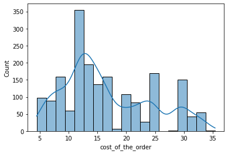

```python
##### The following code plots a histrogram seaborn package
sns.histplot(x = 'cost_of_the_order',data =df, kde =True, );
```

```python
# This code was used from MLS Session 4 to plot a box plot above the histogram.. Property of Great Learning.
# While doing uni-variate analysis of numerical variables we want to study their central tendency
# and dispersion.
# Let us write a function that will help us create a boxplot and histogram for any input numerical
# variable.
# This function takes the numerical column as the input and returns the boxplots
# and histograms for the variable.
# Let us see if this helps us write faster and cleaner code.

# function to plot a boxplot and a histogram along the same scale.


def histogram_boxplot(data, feature, figsize=(12, 7), kde=False, bins=None):
    """
    Boxplot and histogram combined

    data: dataframe
    feature: dataframe column
    figsize: size of figure (default (12,7))
    kde: whether to show the density curve (default False)
    bins: number of bins for histogram (default None)
    """
    f2, (ax_box2, ax_hist2) = plt.subplots(
        nrows=2,  # Number of rows of the subplot grid= 2
        sharex=True,  # x-axis will be shared among all subplots
        gridspec_kw={"height_ratios": (0.25, 0.75)},
        figsize=figsize,
    )  # creating the 2 subplots
    sns.boxplot(
        data=data, x=feature, ax=ax_box2, showmeans=True, color="violet"
    )  # boxplot will be created and a star will indicate the mean value of the column
    sns.histplot(
        data=data, x=feature, kde=kde, ax=ax_hist2, bins=bins, palette="winter"
    ) if bins else sns.histplot(
        data=data, x=feature, kde=kde, ax=ax_hist2
    )  # For histogram
    ax_hist2.axvline(
        data[feature].mean(), color="green", linestyle="--"
    )  # Add mean to the histogram
    ax_hist2.axvline(
        data[feature].median(), color="black", linestyle="-"
    )  # Add median to the histogram
```

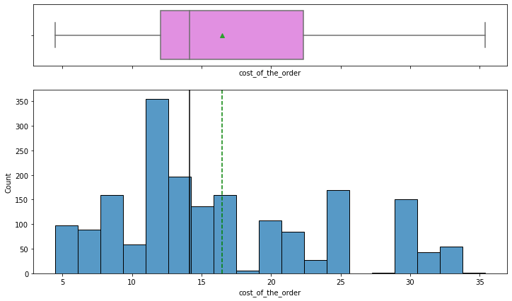

```python
histogram_boxplot(df, 'cost_of_the_order')
```

```python
df['cost_of_the_order'].mode()
```

```
0   12.18000
dtype: float64
```

#### Observation

1. Cost_of_the_order is right skewed with a Mean 16.5 > Median 14.1.
2. The most frequently occuring cost is 12.2 dollars
3. There are no outliers in the data set

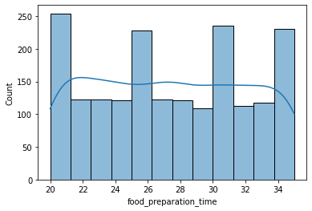

```python
#### The following code plots a histrogram seaborn package
sns.histplot(x = 'food_preparation_time',data =df, kde =True, );
```

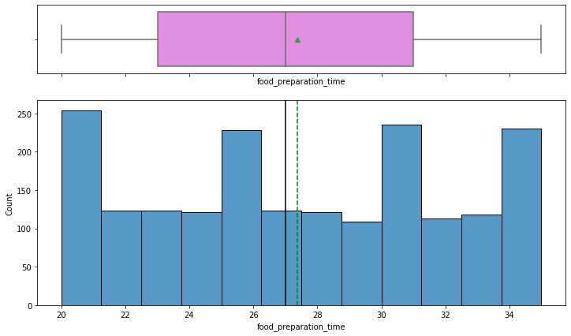

```python
#### This code generates the histogram with the box plot over it
histogram_boxplot(df, 'food_preparation_time')
```

#### Observation:

1. This data is near uniform with frequent preparation times of in the 20-21 , 25-26, 30-31 and 34-35 minute periods.
2. There is a small std deviation of 4.6 mins from the mean of 27 mins. The median of the data is 27 minutes.
3. There are no outliers in the data set.

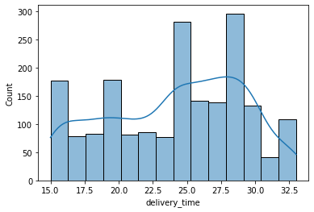

```python
#### The following code plots a histrogram seaborn package
sns.histplot(x = 'delivery_time',data =df, kde =True, );
```

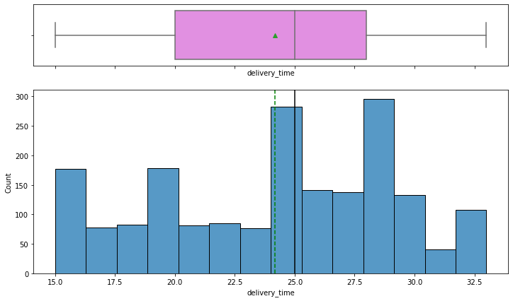

```python
#### This code generates the histogram with the box plot over it
histogram_boxplot(df, 'delivery_time')
```

#### Observation:

1. Delivery time is left skewed with a Mean of 24 less than the Median of 25 minutes.
2. There is a small std deviation of 4.97 mins from the mean of 24 mins.
3. There are no outliers in the data set.

### Question 7: Write the code to find the top 5 restaurants that have received the highest number of orders. (1 mark)

```python
#### This code creates a new column 'order_count' and assigns a value of one for each time an order is counted
df['order_count'] = 1

#### A New dataframe df1 is then created showing the 'restaurant_name' and 'restaurant_counts'
df1 = df[['restaurant_name', 'order_count']].copy()
df1
```

|  | restaurant_name | order_count |
| --- | --- | --- |
| 0 | Hangawi | 1 |
| 1 | Blue Ribbon Sushi Izakaya | 1 |
| 2 | Cafe Habana | 1 |
| 3 | Blue Ribbon Fried Chicken | 1 |
| 4 | Dirty Bird to Go | 1 |
| ... | ... | ... |
| 1893 | Chipotle Mexican Grill $1.99 Delivery | 1 |
| 1894 | The Smile | 1 |
| 1895 | Blue Ribbon Sushi | 1 |
| 1896 | Jack's Wife Freda | 1 |
| 1897 | Blue Ribbon Sushi | 1 |

1898 rows × 2 columns

```python
#### A New dataframe df2 is then created that tallies the number of times each restaurant name is counted
df2 = df1.groupby(by ='restaurant_name')[['order_count']].sum().copy()
df2.reset_index()
```

|  | restaurant_name | order_count |
| --- | --- | --- |
| 0 | 'wichcraft | 1 |
| 1 | 12 Chairs | 4 |
| 2 | 5 Napkin Burger | 5 |
| 3 | 67 Burger | 1 |
| 4 | Alidoro | 1 |
| ... | ... | ... |
| 173 | Zero Otto Nove | 2 |
| 174 | brgr | 2 |
| 175 | da Umberto | 3 |
| 176 | ilili Restaurant | 18 |
| 177 | indikitch | 4 |

178 rows × 2 columns

```python
#### A New dataframe df3 is created that sorts the restaurant_counts values in descending order
df3 =  df2.sort_values( by= ['order_count'], ascending= False)
df3
```

| restaurant_name | order_count |
| --- | --- |
| Shake Shack | 219 |
| The Meatball Shop | 132 |
| Blue Ribbon Sushi | 119 |
| Blue Ribbon Fried Chicken | 96 |
| Parm | 68 |
| ... | ... |
| Klong | 1 |
| Kambi Ramen House | 1 |
| Il Bambino | 1 |
| Hunan Manor | 1 |
| Lamarca Pasta | 1 |

178 rows × 1 columns

```python
#### This code selects all the restaurants with order numbers greater than 10. This data frame dfs is being used to generate a plot to see demand by restaurant. The company requested that demand be analyzed as part of the problem statement in addition to the customer experience.
dfs=df3[df3['order_count']>10]
dfs['restaurant']=dfs.index
dfs
```

| restaurant_name | order_count | restaurant |
| --- | --- | --- |
| Shake Shack | 219 | Shake Shack |
| The Meatball Shop | 132 | The Meatball Shop |
| Blue Ribbon Sushi | 119 | Blue Ribbon Sushi |
| Blue Ribbon Fried Chicken | 96 | Blue Ribbon Fried Chicken |
| Parm | 68 | Parm |
| RedFarm Broadway | 59 | RedFarm Broadway |
| RedFarm Hudson | 55 | RedFarm Hudson |
| TAO | 49 | TAO |
| Han Dynasty | 46 | Han Dynasty |
| Blue Ribbon Sushi Bar & Grill | 44 | Blue Ribbon Sushi Bar & Grill |
| Nobu Next Door | 42 | Nobu Next Door |
| Rubirosa | 37 | Rubirosa |
| Sushi of Gari 46 | 37 | Sushi of Gari 46 |
| Momoya | 30 | Momoya |
| Blue Ribbon Sushi Izakaya | 29 | Blue Ribbon Sushi Izakaya |
| Five Guys Burgers and Fries | 29 | Five Guys Burgers and Fries |
| Bareburger | 27 | Bareburger |
| Tamarind TriBeCa | 27 | Tamarind TriBeCa |
| Jack's Wife Freda | 25 | Jack's Wife Freda |
| Sushi of Gari Tribeca | 24 | Sushi of Gari Tribeca |
| Chipotle Mexican Grill $1.99 Delivery | 23 | Chipotle Mexican Grill $1.99 Delivery |
| Cafe Mogador | 18 | Cafe Mogador |
| The Smile | 18 | The Smile |
| Yama Japanese Restaurant | 18 | Yama Japanese Restaurant |
| ilili Restaurant | 18 | ilili Restaurant |
| Sushi of Gari | 16 | Sushi of Gari |
| The Kati Roll Company | 16 | The Kati Roll Company |
| Cafe Habana | 16 | Cafe Habana |
| Westville Hudson | 15 | Westville Hudson |
| P.J. Clarke's | 15 | P.J. Clarke's |
| J. G. Melon | 15 | J. G. Melon |
| Osteria Morini | 14 | Osteria Morini |
| Hill Country Fried Chicken | 14 | Hill Country Fried Chicken |
| Empanada Mama (closed) | 13 | Empanada Mama (closed) |
| Vanessa's Dumplings | 13 | Vanessa's Dumplings |
| Otto Enoteca Pizzeria | 12 | Otto Enoteca Pizzeria |
| Burger Joint | 12 | Burger Joint |
| S'MAC | 12 | S'MAC |
| Sushi Samba | 11 | Sushi Samba |
| Melt Shop | 11 | Melt Shop |

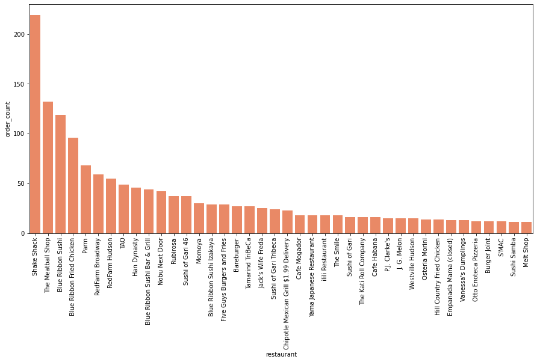

```python
#### This code generates the bar plot of the category "restaurant" vs order numbers shown on the y axis as order_count
plt.figure(figsize=(15, 7)) # To resize the plot
sns.barplot(data = dfs, x = 'restaurant', y = "order_count", ci=None, color = "coral",
            order= dfs.sort_values( by= ['order_count'], ascending= False).index)
plt.xticks(rotation=90) # To rotate the x axis lables
plt.show()
```

```python
#### This code filters the top 5 restaurants in the dataset by order count
df3['order_count'].nlargest(n=5)
```

```
restaurant_name
Shake Shack                  219
The Meatball Shop            132
Blue Ribbon Sushi            119
Blue Ribbon Fried Chicken     96
Parm                          68
Name: order_count, dtype: int64
```

#### Observations:

The analysis indicates that the top 5 restaurants that have received the largest number of orders are

1. Shake Shack = 219 orders
2. The Meatball Shop = 132 orders
3. Blue Ribbon Sushi = 119 orders
4. Blue Ribbon Fried Chicken = 96 orders
5. Parm = 68 orders

### Question 8: Write the code to find the most popular cuisine on weekends. (1 mark)

```python
### This code copies the dataframe with weekend only orders
df4 = df[df['day_of_the_week']=='Weekend'].copy()
df4
```

|  | order_id | customer_id | restaurant_name | cuisine_type | cost_of_the_order | day_of_the_week | rating | food_preparation_time | delivery_time | order_count |
| --- | --- | --- | --- | --- | --- | --- | --- | --- | --- | --- |
| 0 | 1477147 | 337525 | Hangawi | Korean | 30.75000 | Weekend | Not given | 25 | 20 | 1 |
| 1 | 1477685 | 358141 | Blue Ribbon Sushi Izakaya | Japanese | 12.08000 | Weekend | Not given | 25 | 23 | 1 |
| 3 | 1477334 | 106968 | Blue Ribbon Fried Chicken | American | 29.20000 | Weekend | 3 | 25 | 15 | 1 |
| 6 | 1477894 | 157711 | The Meatball Shop | Italian | 6.07000 | Weekend | Not given | 28 | 21 | 1 |
| 11 | 1478437 | 221206 | Empanada Mama (closed) | Mexican | 8.10000 | Weekend | 5 | 23 | 22 | 1 |
| ... | ... | ... | ... | ... | ... | ... | ... | ... | ... | ... |
| 1891 | 1476981 | 138586 | Shake Shack | American | 5.82000 | Weekend | Not given | 22 | 28 | 1 |
| 1892 | 1477473 | 97838 | Han Dynasty | Chinese | 29.15000 | Weekend | Not given | 29 | 21 | 1 |
| 1893 | 1476701 | 292602 | Chipotle Mexican Grill $1.99 Delivery | Mexican | 22.31000 | Weekend | 5 | 31 | 17 | 1 |
| 1894 | 1477421 | 397537 | The Smile | American | 12.18000 | Weekend | 5 | 31 | 19 | 1 |
| 1897 | 1478056 | 120353 | Blue Ribbon Sushi | Japanese | 19.45000 | Weekend | Not given | 28 | 24 | 1 |

1351 rows × 10 columns

```python
#### This code sorts the data by cuisine types
df5 =  df4.sort_values( by= ['cuisine_type'])
df5
```

|  | order_id | customer_id | restaurant_name | cuisine_type | cost_of_the_order | day_of_the_week | rating | food_preparation_time | delivery_time | order_count |
| --- | --- | --- | --- | --- | --- | --- | --- | --- | --- | --- |
| 652 | 1476678 | 91817 | Shake Shack | American | 21.39000 | Weekend | 4 | 28 | 18 | 1 |
| 575 | 1478192 | 54365 | Shake Shack | American | 16.25000 | Weekend | 5 | 27 | 23 | 1 |
| 1107 | 1477591 | 97806 | Shake Shack | American | 31.43000 | Weekend | Not given | 30 | 19 | 1 |
| 1389 | 1476632 | 120385 | Westville Hudson | American | 9.51000 | Weekend | Not given | 27 | 28 | 1 |
| 1653 | 1477434 | 77857 | Shake Shack | American | 29.15000 | Weekend | 5 | 20 | 21 | 1 |
| ... | ... | ... | ... | ... | ... | ... | ... | ... | ... | ... |
| 1333 | 1477182 | 383826 | Song Thai Restaurant & Bar | Thai | 29.20000 | Weekend | 5 | 21 | 28 | 1 |
| 1272 | 1477555 | 361497 | V-Nam Cafe | Vietnamese | 12.13000 | Weekend | 4 | 20 | 26 | 1 |
| 373 | 1477014 | 399520 | Xe May Sandwich Shop | Vietnamese | 7.96000 | Weekend | 5 | 25 | 29 | 1 |
| 746 | 1477189 | 54630 | V-Nam Cafe | Vietnamese | 22.26000 | Weekend | 5 | 33 | 26 | 1 |
| 1554 | 1476957 | 54630 | V-Nam Cafe | Vietnamese | 12.08000 | Weekend | Not given | 31 | 19 | 1 |

1351 rows × 10 columns

```python
### This code creates a new column 'cuisine_type_counts' and assigns a value of one for each time a cuisisne_type is entered
df5['cuisine_type_count'] = 1

### A New dataframe df6 is then created showing the 'cuisine_type' and 'restaurant_name', 'day_of_the_week','food_preparation_time' and 'delivery_time'
df6 = df5[['restaurant_name', 'cuisine_type', 'cuisine_type_count', 'day_of_the_week', 'food_preparation_time', 'delivery_time']].copy()
df6
```

|  | restaurant_name | cuisine_type | cuisine_type_count | day_of_the_week | food_preparation_time | delivery_time |
| --- | --- | --- | --- | --- | --- | --- |
| 652 | Shake Shack | American | 1 | Weekend | 28 | 18 |
| 575 | Shake Shack | American | 1 | Weekend | 27 | 23 |
| 1107 | Shake Shack | American | 1 | Weekend | 30 | 19 |
| 1389 | Westville Hudson | American | 1 | Weekend | 27 | 28 |
| 1653 | Shake Shack | American | 1 | Weekend | 20 | 21 |
| ... | ... | ... | ... | ... | ... | ... |
| 1333 | Song Thai Restaurant & Bar | Thai | 1 | Weekend | 21 | 28 |
| 1272 | V-Nam Cafe | Vietnamese | 1 | Weekend | 20 | 26 |
| 373 | Xe May Sandwich Shop | Vietnamese | 1 | Weekend | 25 | 29 |
| 746 | V-Nam Cafe | Vietnamese | 1 | Weekend | 33 | 26 |
| 1554 | V-Nam Cafe | Vietnamese | 1 | Weekend | 31 | 19 |

1351 rows × 6 columns

```python
#### This code creates a dataframe that shows the sum of the various cuisine types
df7 = df6.groupby( by ='cuisine_type')[['cuisine_type_count']].sum().copy()
df7
```

| cuisine_type | cuisine_type_count |
| --- | --- |
| American | 415 |
| Chinese | 163 |
| French | 13 |
| Indian | 49 |
| Italian | 207 |
| Japanese | 335 |
| Korean | 11 |
| Mediterranean | 32 |
| Mexican | 53 |
| Middle Eastern | 32 |
| Southern | 11 |
| Spanish | 11 |
| Thai | 15 |
| Vietnamese | 4 |

```python
#### This code sorts the cuisine_type_counts in descending order
df8 =  df7.sort_values( by= ['cuisine_type_count'], ascending= False)
df8
```

| cuisine_type | cuisine_type_count |
| --- | --- |
| American | 415 |
| Japanese | 335 |
| Italian | 207 |
| Chinese | 163 |
| Mexican | 53 |
| Indian | 49 |
| Mediterranean | 32 |
| Middle Eastern | 32 |
| Thai | 15 |
| French | 13 |
| Korean | 11 |
| Southern | 11 |
| Spanish | 11 |
| Vietnamese | 4 |

#### Observations:

The most popular cuisine on weekend is American which has a count of 415 orders.

### Question 9: Write the code to find the number of total orders where the cost is above 20 dollars. What is the percentage of such orders in the dataset? (1 mark)

```python
#### This code sorts the cost of the orders in descending order

df9 = df.sort_values( by= ['cost_of_the_order'], ascending =False, inplace =False)
df9
```

|  | order_id | customer_id | restaurant_name | cuisine_type | cost_of_the_order | day_of_the_week | rating | food_preparation_time | delivery_time | order_count |
| --- | --- | --- | --- | --- | --- | --- | --- | --- | --- | --- |
| 573 | 1477814 | 62359 | Pylos | Mediterranean | 35.41000 | Weekday | 4 | 21 | 29 | 1 |
| 1646 | 1477665 | 231061 | Han Dynasty | Chinese | 34.19000 | Weekday | Not given | 21 | 31 | 1 |
| 1762 | 1477700 | 60039 | Blue Ribbon Sushi | Japanese | 33.37000 | Weekday | 3 | 30 | 27 | 1 |
| 1831 | 1476970 | 275689 | Nobu Next Door | Japanese | 33.37000 | Weekend | 4 | 32 | 21 | 1 |
| 1370 | 1478329 | 116992 | Tres Carnes | Mexican | 33.32000 | Weekday | 4 | 21 | 33 | 1 |
| ... | ... | ... | ... | ... | ... | ... | ... | ... | ... | ... |
| 82 | 1477790 | 133617 | Shake Shack | American | 4.75000 | Weekday | 4 | 35 | 28 | 1 |
| 1569 | 1477786 | 145389 | RedFarm Hudson | Chinese | 4.75000 | Weekend | 3 | 23 | 25 | 1 |
| 542 | 1477788 | 270444 | P.J. Clarke's | American | 4.71000 | Weekend | Not given | 23 | 15 | 1 |
| 480 | 1476877 | 53289 | The Loop | Japanese | 4.66000 | Weekend | Not given | 34 | 25 | 1 |
| 624 | 1477349 | 52327 | Nobu Next Door | Japanese | 4.47000 | Weekend | 5 | 28 | 26 | 1 |

1898 rows × 10 columns

```python
#### This code filters the orders that cost more than 20 dollars
df10 = df9[df9['cost_of_the_order']>20]
df10
```

|  | order_id | customer_id | restaurant_name | cuisine_type | cost_of_the_order | day_of_the_week | rating | food_preparation_time | delivery_time | order_count |
| --- | --- | --- | --- | --- | --- | --- | --- | --- | --- | --- |
| 573 | 1477814 | 62359 | Pylos | Mediterranean | 35.41000 | Weekday | 4 | 21 | 29 | 1 |
| 1646 | 1477665 | 231061 | Han Dynasty | Chinese | 34.19000 | Weekday | Not given | 21 | 31 | 1 |
| 1762 | 1477700 | 60039 | Blue Ribbon Sushi | Japanese | 33.37000 | Weekday | 3 | 30 | 27 | 1 |
| 1831 | 1476970 | 275689 | Nobu Next Door | Japanese | 33.37000 | Weekend | 4 | 32 | 21 | 1 |
| 1370 | 1478329 | 116992 | Tres Carnes | Mexican | 33.32000 | Weekday | 4 | 21 | 33 | 1 |
| ... | ... | ... | ... | ... | ... | ... | ... | ... | ... | ... |
| 874 | 1477357 | 5444 | Go! Go! Curry! | Japanese | 20.18000 | Weekend | 3 | 22 | 29 | 1 |
| 175 | 1478093 | 268958 | Barbounia | Mediterranean | 20.18000 | Weekend | 5 | 29 | 19 | 1 |
| 1598 | 1477249 | 351561 | The Kati Roll Company | Indian | 20.13000 | Weekday | Not given | 24 | 31 | 1 |
| 1761 | 1476953 | 252342 | Westville Hudson | American | 20.13000 | Weekend | 4 | 29 | 19 | 1 |
| 1400 | 1477539 | 152675 | Tres Carnes | Mexican | 20.13000 | Weekend | Not given | 35 | 18 | 1 |

555 rows × 10 columns

```python
#### Percentage of such orders in data set where orders are over 20 dollars are
#### len(df10)/len(df9) where len(df10) represents the number of orders entries in
#### the data set and len(df9) represents the number of orders that cost more than 20 dollars

a = len(df10)/len(df)
print('{:.1%}'.format(a))
```

```
29.2%
```

#### Observations:

29.2% of the orders in the data set cost more than 20 dollars

### Question 10: Write the code to find the mean delivery time based on this dataset. (1 mark)

```python
#### This code calculates the mean time of the series 'delivery_time'
b = df9['delivery_time'].mean()

#### This code keeps the expression to 2 decimal places
print('%.2f'%(b))
```

```
24.16
```

#### Observations:

The mean delivery time for orders is 24.2 minutes.

### Question 11: Suppose the company has decided to give a free coupon of 15 dollars to the customer who has spent the maximum amount on a single order. Write the code to find the ID of the customer along with the order details. (1 mark)

```python
df11 = df.sort_values(by =['cost_of_the_order'], ascending = False, inplace = False)
df11
```

|  | order_id | customer_id | restaurant_name | cuisine_type | cost_of_the_order | day_of_the_week | rating | food_preparation_time | delivery_time | order_count |
| --- | --- | --- | --- | --- | --- | --- | --- | --- | --- | --- |
| 573 | 1477814 | 62359 | Pylos | Mediterranean | 35.41000 | Weekday | 4 | 21 | 29 | 1 |
| 1646 | 1477665 | 231061 | Han Dynasty | Chinese | 34.19000 | Weekday | Not given | 21 | 31 | 1 |
| 1762 | 1477700 | 60039 | Blue Ribbon Sushi | Japanese | 33.37000 | Weekday | 3 | 30 | 27 | 1 |
| 1831 | 1476970 | 275689 | Nobu Next Door | Japanese | 33.37000 | Weekend | 4 | 32 | 21 | 1 |
| 1370 | 1478329 | 116992 | Tres Carnes | Mexican | 33.32000 | Weekday | 4 | 21 | 33 | 1 |
| ... | ... | ... | ... | ... | ... | ... | ... | ... | ... | ... |
| 82 | 1477790 | 133617 | Shake Shack | American | 4.75000 | Weekday | 4 | 35 | 28 | 1 |
| 1569 | 1477786 | 145389 | RedFarm Hudson | Chinese | 4.75000 | Weekend | 3 | 23 | 25 | 1 |
| 542 | 1477788 | 270444 | P.J. Clarke's | American | 4.71000 | Weekend | Not given | 23 | 15 | 1 |
| 480 | 1476877 | 53289 | The Loop | Japanese | 4.66000 | Weekend | Not given | 34 | 25 | 1 |
| 624 | 1477349 | 52327 | Nobu Next Door | Japanese | 4.47000 | Weekend | 5 | 28 | 26 | 1 |

1898 rows × 10 columns

```python
#### This code finds the customer with the most expensive single order, from the sorted dataframe above.
df11.iloc[0,:]
```

```
order_id                       1477814
customer_id                      62359
restaurant_name                  Pylos
cuisine_type             Mediterranean
cost_of_the_order             35.41000
day_of_the_week                Weekday
rating                               4
food_preparation_time               21
delivery_time                       29
order_count                          1
Name: 573, dtype: object
```

#### Observations:

Customer_id (62359) order_id (1477814)spent 35.41 dollars on a single order of Mediterranean food at the Pylos Restaurant during the weekday. This customer will receive the free coupon for 15 dollars

### Question 12: Perform bivariate/multivariate analysis to explore relationships between the important variables in the dataset. (7 marks)

```python
#### This code identifies the varios columns in the dataframe
df.columns
```

```
Index(['order_id', 'customer_id', 'restaurant_name', 'cuisine_type',
       'cost_of_the_order', 'day_of_the_week', 'rating',
       'food_preparation_time', 'delivery_time', 'order_count'],
      dtype='object')
```

First we agree on the data to be analyzed from the dataframe. The columns below have been selected for Bivariate/Multivariate Histogram plots:

1. df['cuisine_type']
2. df['cost_of_the_order']
3. df['order_count']
4. df['rating']
5. df['food_preparation_time']
6. df['delivery_time']
7. df['restaurant_name']

```python
df.info()
```

```
<class 'pandas.core.frame.DataFrame'>
RangeIndex: 1898 entries, 0 to 1897
Data columns (total 10 columns):
 #   Column                 Non-Null Count  Dtype
---  ------                 --------------  -----
 0   order_id               1898 non-null   int64
 1   customer_id            1898 non-null   int64
 2   restaurant_name        1898 non-null   category
 3   cuisine_type           1898 non-null   category
 4   cost_of_the_order      1898 non-null   float64
 5   day_of_the_week        1898 non-null   category
 6   rating                 1898 non-null   object
 7   food_preparation_time  1898 non-null   int64
 8   delivery_time          1898 non-null   int64
 9   order_count            1898 non-null   int64
dtypes: category(3), float64(1), int64(5), object(1)
memory usage: 117.6+ KB
```

#### Observation :

From the info above, we can see that rating is an object Dtype. This is probably due to the fact that some entries have string values "Not Given". So rating will not be analyzed at stage.

#### For the Multivariate/Bivariate analysis, first we will prepare a data frame that only contains 'cuisine_type', 'cost_of_the_order', 'day_of_the_week', 'food_preparation_time', and 'delivery_time'

```python
df12=df[['restaurant_name', 'cuisine_type',
       'cost_of_the_order', 'day_of_the_week',
       'food_preparation_time', 'delivery_time']]
df12
```

|  | restaurant_name | cuisine_type | cost_of_the_order | day_of_the_week | food_preparation_time | delivery_time |
| --- | --- | --- | --- | --- | --- | --- |
| 0 | Hangawi | Korean | 30.75000 | Weekend | 25 | 20 |
| 1 | Blue Ribbon Sushi Izakaya | Japanese | 12.08000 | Weekend | 25 | 23 |
| 2 | Cafe Habana | Mexican | 12.23000 | Weekday | 23 | 28 |
| 3 | Blue Ribbon Fried Chicken | American | 29.20000 | Weekend | 25 | 15 |
| 4 | Dirty Bird to Go | American | 11.59000 | Weekday | 25 | 24 |
| ... | ... | ... | ... | ... | ... | ... |
| 1893 | Chipotle Mexican Grill $1.99 Delivery | Mexican | 22.31000 | Weekend | 31 | 17 |
| 1894 | The Smile | American | 12.18000 | Weekend | 31 | 19 |
| 1895 | Blue Ribbon Sushi | Japanese | 25.22000 | Weekday | 31 | 24 |
| 1896 | Jack's Wife Freda | Mediterranean | 12.18000 | Weekday | 23 | 31 |
| 1897 | Blue Ribbon Sushi | Japanese | 19.45000 | Weekend | 28 | 24 |

1898 rows × 6 columns

```python
df12.describe()
```

|  | cost_of_the_order | food_preparation_time | delivery_time |
| --- | --- | --- | --- |
| count | 1898.00000 | 1898.00000 | 1898.00000 |
| mean | 16.49885 | 27.37197 | 24.16175 |
| std | 7.48381 | 4.63248 | 4.97264 |
| min | 4.47000 | 20.00000 | 15.00000 |
| 25% | 12.08000 | 23.00000 | 20.00000 |
| 50% | 14.14000 | 27.00000 | 25.00000 |
| 75% | 22.29750 | 31.00000 | 28.00000 |
| max | 35.41000 | 35.00000 | 33.00000 |

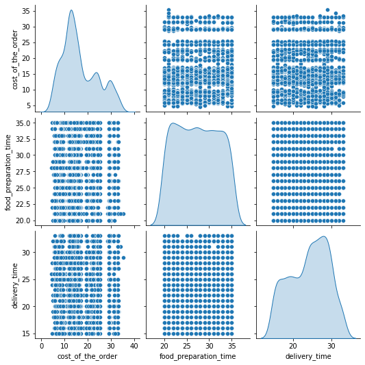

```python
#### This pairplot from the seaborn package looks at relationships between the multiple numerical variables. The histogram plots are naturally
#### smoothed with a Kernel Density Function.
sns.pairplot(df12, diag_kind = 'kde');
```

#### Observation

1. Cost_of_the_order is right skewed with a mean of 16.5 and a Median of 14.1.
2. food_preparation_time has an almost uniform distribution with a Mean time of 27 mins.
3. food_preparation_time has a min time of 20 mins with a max time of 35 mins. The std deviation from the mean is 4.6.
4. delivery_time is left skewed with a Mean of24 mins and a Median time of 25 mins.
5. There is no apparent trends between the variables.

```python
correlation = df12.corr() # creating a 2-D Matrix with correlation plots
correlation
```

|  | cost_of_the_order | food_preparation_time | delivery_time |
| --- | --- | --- | --- |
| cost_of_the_order | 1.00000 | 0.04153 | -0.02995 |
| food_preparation_time | 0.04153 | 1.00000 | 0.01109 |
| delivery_time | -0.02995 | 0.01109 | 1.00000 |

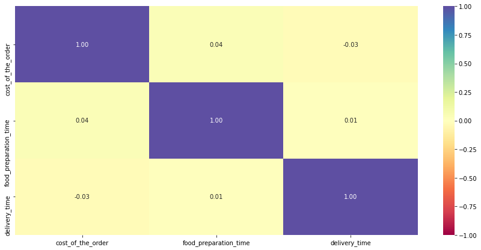

```python
#### This code generates a heat map with the darker colours representing strong correlation between variables and the lighter ones weaker correlations.
plt.figure(figsize=(15, 7))
sns.heatmap(correlation, annot=True, vmin=-1, vmax=1, fmt=".2f", cmap="Spectral")
plt.show()
```

#### Observation:

There doesn't appear to be any correlation between the three variables in the matrix.

Now we will look at some bivariate analyses such as:

1. cuisine_type vs average_food_preparation_time
2. cuisine_type vs average_delivery_time

These analyses will help to identify opportunities for the food aggregator company to focus on that can improve the customer experience.

```python
df13 = df12.groupby('cuisine_type')[['food_preparation_time','delivery_time']].mean()
df13
```

| cuisine_type | food_preparation_time | delivery_time |
| --- | --- | --- |
| American | 27.44007 | 24.19349 |
| Chinese | 27.51163 | 23.85581 |
| French | 26.88889 | 25.33333 |
| Indian | 27.10959 | 24.08219 |
| Italian | 27.48322 | 24.56711 |
| Japanese | 27.51064 | 24.13191 |
| Korean | 25.46154 | 20.92308 |
| Mediterranean | 27.00000 | 23.58696 |
| Mexican | 26.72727 | 24.38961 |
| Middle Eastern | 26.67347 | 24.08163 |
| Southern | 27.58824 | 23.82353 |
| Spanish | 26.91667 | 23.41667 |
| Thai | 27.31579 | 23.15789 |
| Vietnamese | 25.71429 | 26.14286 |

```python
df13['cuisine_type'] = df13.index
df13
```

| cuisine_type | food_preparation_time | delivery_time | cuisine_type |
| --- | --- | --- | --- |
| American | 27.44007 | 24.19349 | American |
| Chinese | 27.51163 | 23.85581 | Chinese |
| French | 26.88889 | 25.33333 | French |
| Indian | 27.10959 | 24.08219 | Indian |
| Italian | 27.48322 | 24.56711 | Italian |
| Japanese | 27.51064 | 24.13191 | Japanese |
| Korean | 25.46154 | 20.92308 | Korean |
| Mediterranean | 27.00000 | 23.58696 | Mediterranean |
| Mexican | 26.72727 | 24.38961 | Mexican |
| Middle Eastern | 26.67347 | 24.08163 | Middle Eastern |
| Southern | 27.58824 | 23.82353 | Southern |
| Spanish | 26.91667 | 23.41667 | Spanish |
| Thai | 27.31579 | 23.15789 | Thai |
| Vietnamese | 25.71429 | 26.14286 | Vietnamese |

```python
len(df13)
```

```
14
```

#### Observation :

There are 14 cuisine types in the dataset

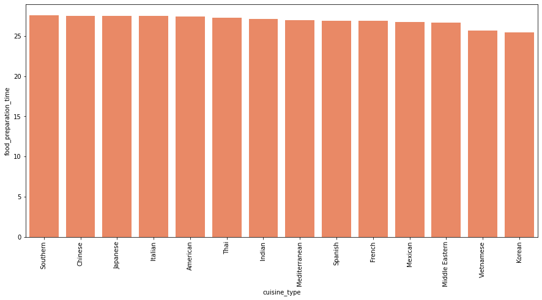

```python
### cuisine_type vs food_preparation_time

plt.figure(figsize=(15, 7)) # To resize the plot
sns.barplot(data = df13, x = 'cuisine_type', y = "food_preparation_time", ci=None, color = "coral",
            order= df12.groupby('cuisine_type')[['food_preparation_time','delivery_time']].mean().sort_values(by=['food_preparation_time','delivery_time'], ascending = False).index)
plt.xticks(rotation=90) # To rotate the x axis lables
plt.show()
```

#### Observations

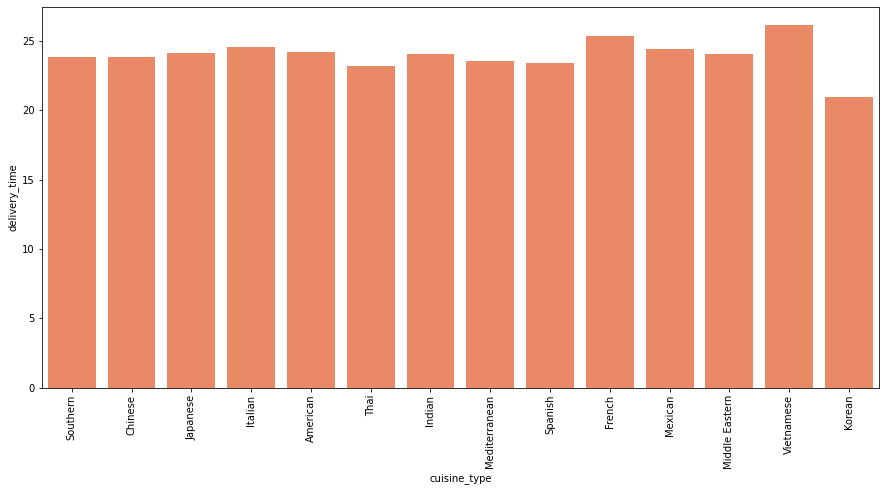

```python
### cuisine_type vs delivery_time

plt.figure(figsize=(15, 7)) # To resize the plot
sns.barplot(data = df13, x = 'cuisine_type', y = "delivery_time", ci=None, color = "coral",
            order= df12.groupby('cuisine_type')[['food_preparation_time','delivery_time']].mean().sort_values(by=['food_preparation_time','delivery_time'], ascending = False).index)
plt.xticks(rotation=90) # To rotate the x axis lables
plt.show()
```

#### Observation :

Most of the cuisines appear to have a delivery time of around 24 minutes.

### Question 13: Suppose the company wants to provide a promotional offer in the advertisement of the restaurants. The condition to get the offer is that the restaurants must have a rating count of more than 50 and the average rating should be greater than 4. Write the code to find the restaurants fulfilling the criteria to get the promotional offer. (2 marks)

```python
### First we delete the rows where ratings are not given

df14 = df.drop(df.index[df['rating'] == 'Not given'])
df14
```

|  | order_id | customer_id | restaurant_name | cuisine_type | cost_of_the_order | day_of_the_week | rating | food_preparation_time | delivery_time | order_count |
| --- | --- | --- | --- | --- | --- | --- | --- | --- | --- | --- |
| 2 | 1477070 | 66393 | Cafe Habana | Mexican | 12.23000 | Weekday | 5 | 23 | 28 | 1 |
| 3 | 1477334 | 106968 | Blue Ribbon Fried Chicken | American | 29.20000 | Weekend | 3 | 25 | 15 | 1 |
| 4 | 1478249 | 76942 | Dirty Bird to Go | American | 11.59000 | Weekday | 4 | 25 | 24 | 1 |
| 5 | 1477224 | 147468 | Tamarind TriBeCa | Indian | 25.22000 | Weekday | 3 | 20 | 24 | 1 |
| 7 | 1477859 | 89574 | Barbounia | Mediterranean | 5.97000 | Weekday | 3 | 33 | 30 | 1 |
| ... | ... | ... | ... | ... | ... | ... | ... | ... | ... | ... |
| 1889 | 1478190 | 94152 | RedFarm Broadway | Chinese | 8.68000 | Weekday | 3 | 33 | 30 | 1 |
| 1890 | 1477316 | 164776 | TAO | Japanese | 15.67000 | Weekend | 5 | 20 | 22 | 1 |
| 1893 | 1476701 | 292602 | Chipotle Mexican Grill $1.99 Delivery | Mexican | 22.31000 | Weekend | 5 | 31 | 17 | 1 |
| 1894 | 1477421 | 397537 | The Smile | American | 12.18000 | Weekend | 5 | 31 | 19 | 1 |
| 1896 | 1477513 | 64151 | Jack's Wife Freda | Mediterranean | 12.18000 | Weekday | 5 | 23 | 31 | 1 |

1162 rows × 10 columns

```python
## Next we do a check on the data types and ensure no data is missing.

df14.info()
```

```
<class 'pandas.core.frame.DataFrame'>
Int64Index: 1162 entries, 2 to 1896
Data columns (total 10 columns):
 #   Column                 Non-Null Count  Dtype
---  ------                 --------------  -----
 0   order_id               1162 non-null   int64
 1   customer_id            1162 non-null   int64
 2   restaurant_name        1162 non-null   category
 3   cuisine_type           1162 non-null   category
 4   cost_of_the_order      1162 non-null   float64
 5   day_of_the_week        1162 non-null   category
 6   rating                 1162 non-null   object
 7   food_preparation_time  1162 non-null   int64
 8   delivery_time          1162 non-null   int64
 9   order_count            1162 non-null   int64
dtypes: category(3), float64(1), int64(5), object(1)
memory usage: 83.4+ KB
```

#### Observation:

Here we notice that rating is of type object. This will have to be converted to int64 to conduct further numeric analysis on rating types.

```python
## Here we convert 'rating' type from object to 'int64'
df14.rating =df14.rating.astype('int')
```

```python
#### Here we do a data type check on df14 to ensure we are successful in converting 'rating' to integer type from 'object'
df14.info()
```

```
<class 'pandas.core.frame.DataFrame'>
Int64Index: 1162 entries, 2 to 1896
Data columns (total 10 columns):
 #   Column                 Non-Null Count  Dtype
---  ------                 --------------  -----
 0   order_id               1162 non-null   int64
 1   customer_id            1162 non-null   int64
 2   restaurant_name        1162 non-null   category
 3   cuisine_type           1162 non-null   category
 4   cost_of_the_order      1162 non-null   float64
 5   day_of_the_week        1162 non-null   category
 6   rating                 1162 non-null   int32
 7   food_preparation_time  1162 non-null   int64
 8   delivery_time          1162 non-null   int64
 9   order_count            1162 non-null   int64
dtypes: category(3), float64(1), int32(1), int64(5)
memory usage: 78.9 KB
```

```python
#### This code looks at the stats of the 1162 orders that had rating data
df14.describe()
```

|  | order_id | customer_id | cost_of_the_order | rating | food_preparation_time | delivery_time | order_count |
| --- | --- | --- | --- | --- | --- | --- | --- |
| count | 1162.00000 | 1162.00000 | 1162.00000 | 1162.00000 | 1162.00000 | 1162.00000 | 1162.00000 |
| mean | 1477519.64286 | 171939.47160 | 16.76077 | 4.34423 | 27.38124 | 24.15404 | 1.00000 |
| std | 546.87130 | 114551.21503 | 7.57258 | 0.74148 | 4.67792 | 4.93100 | 0.00000 |
| min | 1476547.00000 | 5139.00000 | 4.47000 | 3.00000 | 20.00000 | 15.00000 | 1.00000 |
| 25% | 1477062.25000 | 77540.00000 | 12.13000 | 4.00000 | 23.00000 | 20.00000 | 1.00000 |
| 50% | 1477523.50000 | 128655.50000 | 14.60000 | 5.00000 | 27.00000 | 25.00000 | 1.00000 |
| 75% | 1477991.75000 | 276066.25000 | 22.75000 | 5.00000 | 32.00000 | 28.00000 | 1.00000 |
| max | 1478444.00000 | 403019.00000 | 35.41000 | 5.00000 | 35.00000 | 33.00000 | 1.00000 |

```python
## Here we group the data by restaurant name and rating sum
df15 = df14.groupby(by ='restaurant_name')[['rating']].sum().copy()
df15

df16 = df15.rename( columns ={'rating':'rating sum'})
df16
```

| restaurant_name | rating sum |
| --- | --- |
| 'wichcraft | 5 |
| 12 Chairs | 9 |
| 5 Napkin Burger | 8 |
| 67 Burger | 5 |
| Alidoro | 0 |
| ... | ... |
| Zero Otto Nove | 4 |
| brgr | 3 |
| da Umberto | 5 |
| ilili Restaurant | 54 |
| indikitch | 9 |

178 rows × 1 columns

```python
## Here we sort the df16 by largest value first
df17 = df16.sort_values( by= ['rating sum'], ascending =False)
df17
```

| restaurant_name | rating sum |
| --- | --- |
| Shake Shack | 569 |
| The Meatball Shop | 379 |
| Blue Ribbon Sushi | 308 |
| Blue Ribbon Fried Chicken | 277 |
| RedFarm Broadway | 174 |
| ... | ... |
| Coppola's East | 0 |
| Crema Restaurante | 0 |
| Gaia Italian Cafe | 0 |
| Tarallucci e Vino Restaurant | 0 |
| Lamarca Pasta | 0 |

178 rows × 1 columns

```python
#### This codes ensures that there are no restaurant entries with ratings = 0
#### This is done as an additional filter to the command to remove rows where ratings are not given
df17[df17['rating sum']>0]
```

| restaurant_name | rating sum |
| --- | --- |
| Shake Shack | 569 |
| The Meatball Shop | 379 |
| Blue Ribbon Sushi | 308 |
| Blue Ribbon Fried Chicken | 277 |
| RedFarm Broadway | 174 |
| ... | ... |
| Byblos Restaurant | 3 |
| Pepe Giallo | 3 |
| Nha Trang One | 3 |
| Sushi Choshi | 3 |
| Sarabeth's West | 3 |

156 rows × 1 columns

#### Observation

The 1162 orders that are rated in the database are split amongst 156 restaurants.

```python
## After sorting the rating sum values, we select the rating sum values greater than 50. Twenty five rating sums are greater than 50.
df18 = df17[df17['rating sum']>50]
df18
```

| restaurant_name | rating sum |
| --- | --- |
| Shake Shack | 569 |
| The Meatball Shop | 379 |
| Blue Ribbon Sushi | 308 |
| Blue Ribbon Fried Chicken | 277 |
| RedFarm Broadway | 174 |
| Parm | 161 |
| RedFarm Hudson | 142 |
| TAO | 122 |
| Han Dynasty | 102 |
| Blue Ribbon Sushi Bar & Grill | 101 |
| Nobu Next Door | 100 |
| Rubirosa | 99 |
| Momoya | 94 |
| Tamarind TriBeCa | 88 |
| Jack's Wife Freda | 82 |
| Five Guys Burgers and Fries | 82 |
| Blue Ribbon Sushi Izakaya | 78 |
| Sushi of Gari 46 | 72 |
| Bareburger | 69 |
| Chipotle Mexican Grill $1.99 Delivery | 63 |
| Sushi of Gari Tribeca | 60 |
| Cafe Mogador | 54 |
| ilili Restaurant | 54 |
| J. G. Melon | 53 |
| The Smile | 53 |

```python
df18.shape
```

```
(25, 1)
```

```python
## Here we group the data by restaurant name and average rating
df19 = df14.groupby(by ='restaurant_name')[['rating']].mean().copy()
df19
df20 = df19.rename( columns ={'rating':'average rating'})
df20
```

| restaurant_name | average rating |
| --- | --- |
| 'wichcraft | 5.00000 |
| 12 Chairs | 4.50000 |
| 5 Napkin Burger | 4.00000 |
| 67 Burger | 5.00000 |
| Alidoro | NaN |
| ... | ... |
| Zero Otto Nove | 4.00000 |
| brgr | 3.00000 |
| da Umberto | 5.00000 |
| ilili Restaurant | 4.15385 |
| indikitch | 4.50000 |

178 rows × 1 columns

```python
df21 = df20[df20['average rating']>4]
df21
```

| restaurant_name | average rating |
| --- | --- |
| 'wichcraft | 5.00000 |
| 12 Chairs | 4.50000 |
| 67 Burger | 5.00000 |
| Amma | 4.50000 |
| Anjappar Chettinad | 5.00000 |
| ... | ... |
| Yama 49 | 5.00000 |
| Yama Japanese Restaurant | 4.50000 |
| da Umberto | 5.00000 |
| ilili Restaurant | 4.15385 |
| indikitch | 4.50000 |

110 rows × 1 columns

```python
#### After merging data frames 21 (average ratings > 4) and data frame 18 (rating sums > 50), we obtain the list of restaurants eligible for the promotional offer.
df_merge = df21.merge(df18, on = 'restaurant_name', how = 'inner')
df_merge
```

| restaurant_name | average rating | rating sum |
| --- | --- | --- |
| Bareburger | 4.05882 | 69 |
| Blue Ribbon Fried Chicken | 4.32812 | 277 |
| Blue Ribbon Sushi | 4.21918 | 308 |
| Blue Ribbon Sushi Bar & Grill | 4.59091 | 101 |
| Blue Ribbon Sushi Izakaya | 4.33333 | 78 |
| Cafe Mogador | 4.15385 | 54 |
| Chipotle Mexican Grill $1.99 Delivery | 4.20000 | 63 |
| Five Guys Burgers and Fries | 4.55556 | 82 |
| Han Dynasty | 4.43478 | 102 |
| J. G. Melon | 4.41667 | 53 |
| Jack's Wife Freda | 4.31579 | 82 |
| Momoya | 4.27273 | 94 |
| Nobu Next Door | 4.34783 | 100 |
| Parm | 4.12821 | 161 |
| RedFarm Broadway | 4.24390 | 174 |
| RedFarm Hudson | 4.17647 | 142 |
| Rubirosa | 4.12500 | 99 |
| Shake Shack | 4.27820 | 569 |
| Sushi of Gari 46 | 4.23529 | 72 |
| Sushi of Gari Tribeca | 4.61538 | 60 |
| TAO | 4.35714 | 122 |
| Tamarind TriBeCa | 4.40000 | 88 |
| The Meatball Shop | 4.51190 | 379 |
| The Smile | 4.41667 | 53 |
| ilili Restaurant | 4.15385 | 54 |

```python
df_merge.shape
```

```
(25, 2)
```

```python
#### This code saves the rating sums > 50 data base as a csv
df18.to_csv('df18.csv')
```

```python
#### This code saves the rating average > 4 database as a csv
df21.to_csv('df21.csv')
```

### Question 14: Suppose the company charges the restaurant 25% on the orders having cost greater than 20 dollars and 15% on the orders having cost greater than 5 dollars. Write the code to find the net revenue generated on all the orders given in the dataset. (2 marks)

```python
#### This code creates a dataframe with just the restaurant name and cost of the orders from the original dataset.
df22 = df[['restaurant_name','cost_of_the_order']].copy()
df23= df22.sort_values(by = ['cost_of_the_order'], ascending = False)
df23
```

|  | restaurant_name | cost_of_the_order |
| --- | --- | --- |
| 573 | Pylos | 35.41000 |
| 1646 | Han Dynasty | 34.19000 |
| 1762 | Blue Ribbon Sushi | 33.37000 |
| 1831 | Nobu Next Door | 33.37000 |
| 1370 | Tres Carnes | 33.32000 |
| ... | ... | ... |
| 82 | Shake Shack | 4.75000 |
| 1569 | RedFarm Hudson | 4.75000 |
| 542 | P.J. Clarke's | 4.71000 |
| 480 | The Loop | 4.66000 |
| 624 | Nobu Next Door | 4.47000 |

1898 rows × 2 columns

```python
#### This code creates a revenue column with a temporary value of 0 assigned to all rows
df23['revenue'] = 0
df23
```

|  | restaurant_name | cost_of_the_order | revenue |
| --- | --- | --- | --- |
| 573 | Pylos | 35.41000 | 0 |
| 1646 | Han Dynasty | 34.19000 | 0 |
| 1762 | Blue Ribbon Sushi | 33.37000 | 0 |
| 1831 | Nobu Next Door | 33.37000 | 0 |
| 1370 | Tres Carnes | 33.32000 | 0 |
| ... | ... | ... | ... |
| 82 | Shake Shack | 4.75000 | 0 |
| 1569 | RedFarm Hudson | 4.75000 | 0 |
| 542 | P.J. Clarke's | 4.71000 | 0 |
| 480 | The Loop | 4.66000 | 0 |
| 624 | Nobu Next Door | 4.47000 | 0 |

1898 rows × 3 columns

```python
#### This code filters orders costing more than 20 dollars and calulates the revenue generated by applying 20% to these values. These values are then assigned to the revenue column.
df24 =  df23[df23['cost_of_the_order']>20]
df24.loc[:,'revenue'] = df24['cost_of_the_order']*0.25
df24
```

|  | restaurant_name | cost_of_the_order | revenue |
| --- | --- | --- | --- |
| 573 | Pylos | 35.41000 | 8.85250 |
| 1646 | Han Dynasty | 34.19000 | 8.54750 |
| 1762 | Blue Ribbon Sushi | 33.37000 | 8.34250 |
| 1831 | Nobu Next Door | 33.37000 | 8.34250 |
| 1370 | Tres Carnes | 33.32000 | 8.33000 |
| ... | ... | ... | ... |
| 874 | Go! Go! Curry! | 20.18000 | 5.04500 |
| 175 | Barbounia | 20.18000 | 5.04500 |
| 1598 | The Kati Roll Company | 20.13000 | 5.03250 |
| 1761 | Westville Hudson | 20.13000 | 5.03250 |
| 1400 | Tres Carnes | 20.13000 | 5.03250 |

555 rows × 3 columns

```python
#### This code filters orders costing more than 5 dollars but less than 20 dollars and calulates the revenue generated by applying 15% to these values
df25 = df23[(df23['cost_of_the_order']>5) & (df23['cost_of_the_order']<20)]

df25.loc[:, 'revenue'] = df25['cost_of_the_order']*0.15
df25
```

|  | restaurant_name | cost_of_the_order | revenue |
| --- | --- | --- | --- |
| 974 | Carmine's | 19.98000 | 2.99700 |
| 1339 | Empanada Mama (closed) | 19.98000 | 2.99700 |
| 39 | Shake Shack | 19.89000 | 2.98350 |
| 48 | Blue Ribbon Fried Chicken | 19.89000 | 2.98350 |
| 1448 | Shake Shack | 19.74000 | 2.96100 |
| ... | ... | ... | ... |
| 601 | indikitch | 5.58000 | 0.83700 |
| 1649 | Shake Shack | 5.53000 | 0.82950 |
| 802 | RedFarm Broadway | 5.48000 | 0.82200 |
| 1095 | The Kati Roll Company | 5.34000 | 0.80100 |
| 1491 | The Meatball Shop | 5.05000 | 0.75750 |

1334 rows × 3 columns

```python
#### This code finds the sum of the revenues generated
#### a = the revenues generated for orders above 20 dollars
a= df24['revenue'].sum()

#### b = the revenues generated for orders greater than 5 dollars but less than 20 dollars
b= df25['revenue'].sum()

a+b
```

```
6166.303
```

#### Observations:

A total of $ 6166.30 cents is generated in revenue from all the orders.

### Question 15: Suppose the company wants to analyze the total time required to deliver the food. Write the code to find out the percentage of orders that have more than 60 minutes of total delivery time. (2 marks)

Note: The total delivery time is the summation of the food preparation time and delivery time.

```python
#### This code sums the delivery times across the rows
df26=df[['restaurant_name','food_preparation_time','delivery_time', 'day_of_the_week']]
df26['Total_delivery_time'] = df26.loc[:,'food_preparation_time': 'delivery_time'].sum(axis =1)
df26
```

|  | restaurant_name | food_preparation_time | delivery_time | day_of_the_week | Total_delivery_time |
| --- | --- | --- | --- | --- | --- |
| 0 | Hangawi | 25 | 20 | Weekend | 45 |
| 1 | Blue Ribbon Sushi Izakaya | 25 | 23 | Weekend | 48 |
| 2 | Cafe Habana | 23 | 28 | Weekday | 51 |
| 3 | Blue Ribbon Fried Chicken | 25 | 15 | Weekend | 40 |
| 4 | Dirty Bird to Go | 25 | 24 | Weekday | 49 |
| ... | ... | ... | ... | ... | ... |
| 1893 | Chipotle Mexican Grill $1.99 Delivery | 31 | 17 | Weekend | 48 |
| 1894 | The Smile | 31 | 19 | Weekend | 50 |
| 1895 | Blue Ribbon Sushi | 31 | 24 | Weekday | 55 |
| 1896 | Jack's Wife Freda | 23 | 31 | Weekday | 54 |
| 1897 | Blue Ribbon Sushi | 28 | 24 | Weekend | 52 |

1898 rows × 5 columns

```python
#### This code finds the percentage of orders with a time greater than 60 minutes and rounds it off to one decimal place.

round(len(df26[df26['Total_delivery_time']>60])/len(df26['Total_delivery_time'])*100,1)
```

```
10.5
```

```python
#### This code finds the mean Total_delivery_time rounded to one decimal place
round(df26['Total_delivery_time'].mean(),1)
```

```
51.5
```

#### Observations:

10.5 % of the orders have a delivery time greater than 60 mins, while the average total delivery time of all the orders is 51.5 minutes.

### Question 16: Suppose the company wants to analyze the delivery time of the orders on weekdays and weekends. Write the code to find the mean delivery time on weekdays and weekends. Write your observations on the results. (2 marks)

```python
#### This code filters the datbase to show preparation and delivery times on the weekend only
df27 = df26[df26['day_of_the_week']== 'Weekend']
df27
```

|  | restaurant_name | food_preparation_time | delivery_time | day_of_the_week | Total_delivery_time |
| --- | --- | --- | --- | --- | --- |
| 0 | Hangawi | 25 | 20 | Weekend | 45 |
| 1 | Blue Ribbon Sushi Izakaya | 25 | 23 | Weekend | 48 |
| 3 | Blue Ribbon Fried Chicken | 25 | 15 | Weekend | 40 |
| 6 | The Meatball Shop | 28 | 21 | Weekend | 49 |
| 11 | Empanada Mama (closed) | 23 | 22 | Weekend | 45 |
| ... | ... | ... | ... | ... | ... |
| 1891 | Shake Shack | 22 | 28 | Weekend | 50 |
| 1892 | Han Dynasty | 29 | 21 | Weekend | 50 |
| 1893 | Chipotle Mexican Grill $1.99 Delivery | 31 | 17 | Weekend | 48 |
| 1894 | The Smile | 31 | 19 | Weekend | 50 |
| 1897 | Blue Ribbon Sushi | 28 | 24 | Weekend | 52 |

1351 rows × 5 columns

```python
round(df27['Total_delivery_time'].mean(),0)
```

```
50.0
```

```python
#### This code filters the datbase to show preparation and delivery times on the weekday only
df28 = df26[df26['day_of_the_week']== 'Weekday']
df28
```

|  | restaurant_name | food_preparation_time | delivery_time | day_of_the_week | Total_delivery_time |
| --- | --- | --- | --- | --- | --- |
| 2 | Cafe Habana | 23 | 28 | Weekday | 51 |
| 4 | Dirty Bird to Go | 25 | 24 | Weekday | 49 |
| 5 | Tamarind TriBeCa | 20 | 24 | Weekday | 44 |
| 7 | Barbounia | 33 | 30 | Weekday | 63 |
| 8 | Anjappar Chettinad | 21 | 26 | Weekday | 47 |
| ... | ... | ... | ... | ... | ... |
| 1878 | Blue Ribbon Sushi | 27 | 31 | Weekday | 58 |
| 1885 | Shake Shack | 27 | 29 | Weekday | 56 |
| 1889 | RedFarm Broadway | 33 | 30 | Weekday | 63 |
| 1895 | Blue Ribbon Sushi | 31 | 24 | Weekday | 55 |
| 1896 | Jack's Wife Freda | 23 | 31 | Weekday | 54 |

547 rows × 5 columns

```python
round(df28['Total_delivery_time'].mean(),0)
```

```
56.0
```

```python
#### We can also look at just the delivery times meaning the time taken for the delivery person to deliver the foodpackage (not inclusive of food preparation times)

#### This code looks at delivery time on weekend
round(df27['delivery_time'].mean(),0)
```

```
22.0
```

```python
#### This code looks at delivery time on weekday
round(df28['delivery_time'].mean(),0)
```

```
28.0
```

#### Observations:

1. Total_delivery_time is on average 56 minutes on weekdays and 50 mins on weekends.
2. Hence it is 6 minutes longer during the week.
3. Additionally, delivery_time from the restaurant to the customer is on average 28 minutes on weekdays and 22 minutes on weekends. Hence it is also 6 minutes longer during the week.

Since the focus of this study is that of the food aggregator company to find ways to improve customer satisfaction, further analysis is warranted to see if it is the 6 minutes difference in delivery times between weekend and week days that is attributed to some of the lower ratings below 4 in the data set. This analysis is done below where we look at all the restaurants with average ratings below 4

```python
#### Here we group the data by restaurant name with rating, delivery time and food preparation time as columns
df29 = df14.groupby('restaurant_name')['rating','delivery_time','food_preparation_time'].mean()
df29
```

| restaurant_name | rating | delivery_time | food_preparation_time |
| --- | --- | --- | --- |
| 'wichcraft | 5.00000 | 28.00000 | 28.00000 |
| 12 Chairs | 4.50000 | 29.00000 | 27.50000 |
| 5 Napkin Burger | 4.00000 | 21.00000 | 26.50000 |
| 67 Burger | 5.00000 | 28.00000 | 20.00000 |
| Alidoro | NaN | NaN | NaN |
| ... | ... | ... | ... |
| Zero Otto Nove | 4.00000 | 25.00000 | 29.00000 |
| brgr | 3.00000 | 26.00000 | 24.00000 |
| da Umberto | 5.00000 | 30.00000 | 20.00000 |
| ilili Restaurant | 4.15385 | 25.00000 | 26.69231 |
| indikitch | 4.50000 | 28.00000 | 26.50000 |

178 rows × 3 columns

```python
#### This code looks at the stats of the 1162 orders that had ratings data in the dataset.
df29.describe()
```

|  | rating | delivery_time | food_preparation_time |
| --- | --- | --- | --- |
| count | 156.00000 | 156.00000 | 156.00000 |
| mean | 4.39781 | 24.48628 | 26.89802 |
| std | 0.55206 | 3.68222 | 3.45198 |
| min | 3.00000 | 15.00000 | 20.00000 |
| 25% | 4.00000 | 22.40000 | 24.87500 |
| 50% | 4.42572 | 24.51471 | 27.00000 |
| 75% | 5.00000 | 26.70000 | 28.70798 |
| max | 5.00000 | 33.00000 | 35.00000 |

#### Observation:

1. There are 156 rating counts available from the 1162 orders that are rated
2. This confirms that 156 restaurants had rating data

```python
#### As a quick analysis we can check to see the correlation between the average ratings for the 178 restaurants, the preparation times
#### and delivery times

correlation1 = df29.corr()
correlation1
```

|  | rating | delivery_time | food_preparation_time |
| --- | --- | --- | --- |
| rating | 1.00000 | -0.00458 | -0.03450 |
| delivery_time | -0.00458 | 1.00000 | 0.04938 |
| food_preparation_time | -0.03450 | 0.04938 | 1.00000 |

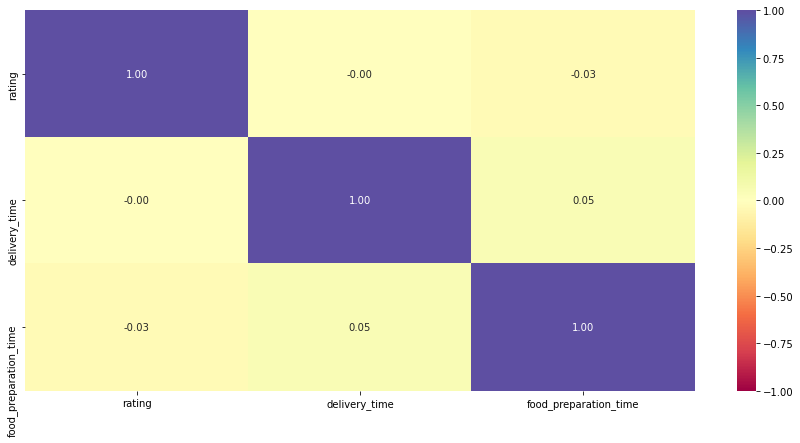

```python
#### This code generates a heat map with the darker colours representing strong correlation between variables and the lighter ones weaker correlations.
#### This is the correlation heat map for the 156 restaurants (1162 orders) with rating data available
plt.figure(figsize=(15, 7))
sns.heatmap(correlation1, annot=True, vmin=-1, vmax=1, fmt=".2f", cmap="Spectral")
plt.show()
```

#### Observation :

1. There is a very small negative correlation between ratings and the times.
2. While it is expected that as times go up ratings go down, the small magnitude indicates that the times do not have any material impact on the ratings given.

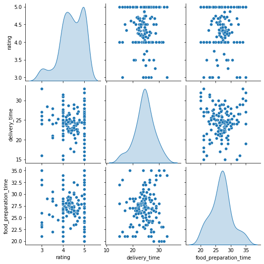

```python
#### This code is a pairplot that takes looks for any trends between the variables for the 1162 orders that had ratings
sns.pairplot(df29, diag_kind = 'kde');
```

#### Observations

1. For the 1162 orders that had ratings we can see that the rating is left skewed with most of the data in the 4 to 5 category.
2. These 1162 orders are split amongst 156 restaurants
3. The delivery time is a normal distribution with a mean of around 24 mins
4. The food preparation time is a normal distribution with a mean of around 27 mins

```python
#### This code filters out all the ratings above 4, so we can look at the lower ratings below 4
df30 =df29[df29['rating']< 4]

#### Total delivery time (avg) is calculated as the sum of the average delivery and food preparation times
df30['Total_delivery_time'] = df30.loc[:,'delivery_time': 'food_preparation_time'].sum(axis =1)
df31= df30.sort_values(by = ['rating'], ascending = False)
df31
```

| restaurant_name | rating | delivery_time | food_preparation_time | Total_delivery_time |
| --- | --- | --- | --- | --- |
| Waverly Diner | 3.75000 | 25.25000 | 24.50000 | 49.75000 |
| Sarabeth's East | 3.66667 | 24.33333 | 27.66667 | 52.00000 |
| Pylos | 3.50000 | 26.25000 | 25.25000 | 51.50000 |
| Don's Bogam BBQ & Wine Bar | 3.50000 | 21.00000 | 29.00000 | 50.00000 |
| Go! Go! Curry! | 3.50000 | 28.00000 | 22.00000 | 50.00000 |
| The Odeon | 3.50000 | 24.00000 | 30.50000 | 54.50000 |
| Terakawa Ramen | 3.50000 | 20.50000 | 28.50000 | 49.00000 |
| Blue Ribbon Brooklyn | 3.33333 | 25.00000 | 25.66667 | 50.66667 |
| Cafeteria | 3.25000 | 28.50000 | 29.00000 | 57.50000 |
| Byblos Restaurant | 3.00000 | 16.00000 | 33.00000 | 49.00000 |
| Pepe Giallo | 3.00000 | 24.00000 | 32.00000 | 56.00000 |
| Sarabeth's West | 3.00000 | 33.00000 | 21.00000 | 54.00000 |
| Sushi Choshi | 3.00000 | 27.00000 | 35.00000 | 62.00000 |
| Nha Trang One | 3.00000 | 24.00000 | 23.00000 | 47.00000 |
| Haveli Indian Restaurant | 3.00000 | 25.00000 | 23.50000 | 48.50000 |
| Woorijip | 3.00000 | 26.00000 | 26.00000 | 52.00000 |
| brgr | 3.00000 | 26.00000 | 24.00000 | 50.00000 |

```python
df31['restaurant_name']= df31.index
df31
```

| restaurant_name | rating | delivery_time | food_preparation_time | Total_delivery_time | restaurant_name |
| --- | --- | --- | --- | --- | --- |
| Waverly Diner | 3.75000 | 25.25000 | 24.50000 | 49.75000 | Waverly Diner |
| Sarabeth's East | 3.66667 | 24.33333 | 27.66667 | 52.00000 | Sarabeth's East |
| Pylos | 3.50000 | 26.25000 | 25.25000 | 51.50000 | Pylos |
| Don's Bogam BBQ & Wine Bar | 3.50000 | 21.00000 | 29.00000 | 50.00000 | Don's Bogam BBQ & Wine Bar |
| Go! Go! Curry! | 3.50000 | 28.00000 | 22.00000 | 50.00000 | Go! Go! Curry! |
| The Odeon | 3.50000 | 24.00000 | 30.50000 | 54.50000 | The Odeon |
| Terakawa Ramen | 3.50000 | 20.50000 | 28.50000 | 49.00000 | Terakawa Ramen |
| Blue Ribbon Brooklyn | 3.33333 | 25.00000 | 25.66667 | 50.66667 | Blue Ribbon Brooklyn |
| Cafeteria | 3.25000 | 28.50000 | 29.00000 | 57.50000 | Cafeteria |
| Byblos Restaurant | 3.00000 | 16.00000 | 33.00000 | 49.00000 | Byblos Restaurant |
| Pepe Giallo | 3.00000 | 24.00000 | 32.00000 | 56.00000 | Pepe Giallo |
| Sarabeth's West | 3.00000 | 33.00000 | 21.00000 | 54.00000 | Sarabeth's West |
| Sushi Choshi | 3.00000 | 27.00000 | 35.00000 | 62.00000 | Sushi Choshi |
| Nha Trang One | 3.00000 | 24.00000 | 23.00000 | 47.00000 | Nha Trang One |
| Haveli Indian Restaurant | 3.00000 | 25.00000 | 23.50000 | 48.50000 | Haveli Indian Restaurant |
| Woorijip | 3.00000 | 26.00000 | 26.00000 | 52.00000 | Woorijip |
| brgr | 3.00000 | 26.00000 | 24.00000 | 50.00000 | brgr |

```python
#### This code looks at the shape of the data and from the result, there are 17 companies out of the 1162
#### that have ratings below 4
df31.shape
```

```
(17, 5)
```

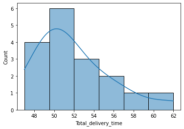

```python
#### This code plots a histogram of the Total delivery times of the 17 restaurants thathave ratings below 4.
sns.histplot(x = 'Total_delivery_time', data = df31, kde = True);
```

```python
#### This code looks at the statistics of the 17 companies that have poor ratings
df31.describe()
```

|  | rating | delivery_time | food_preparation_time | Total_delivery_time |
| --- | --- | --- | --- | --- |
| count | 17.00000 | 17.00000 | 17.00000 | 17.00000 |
| mean | 3.26471 | 24.93137 | 27.03431 | 51.96569 |
| std | 0.27832 | 3.65282 | 4.01765 | 3.79819 |
| min | 3.00000 | 16.00000 | 21.00000 | 47.00000 |
| 25% | 3.00000 | 24.00000 | 24.00000 | 49.75000 |
| 50% | 3.25000 | 25.00000 | 26.00000 | 50.66667 |
| 75% | 3.50000 | 26.25000 | 29.00000 | 54.00000 |
| max | 3.75000 | 33.00000 | 35.00000 | 62.00000 |

```python
correlation2 = df31.corr()# creating a 2-D Matrix with correlation plots
```

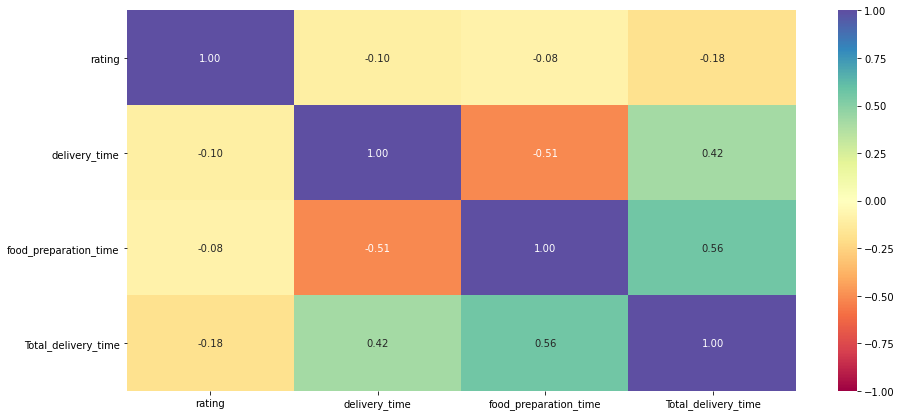

```python
#### This code generates a heat map with the darker colours representing strong correlation between variables and the lighter ones weaker correlations.
#### This is the correlation heat map for the 17 companies with and average rating less than 4
plt.figure(figsize=(15, 7))
sns.heatmap(correlation2, annot=True, vmin=-1, vmax=1, fmt=".2f", cmap="Spectral")
plt.show()
```

#### Observation:

Of the 17 companies that have poor ratings below 4

1. We can see that the mean delivery and food preparation times of 25 and 27 mins respectively
2. These times are close to that of the companies that have ratings above 4.
3. The mean total_delivery_times of 52 mins are also in line with restaurants that have ratings above 4.
4. Only one these 17 companies have times greater than 60 mins. This means that there is some other factor contributing to the low ratings that these restaurants receive. A closer look has to be made, on what is being measured in the rating app to determine the value obtained.

```python
### Conclusion and Recommendations
```

### **Question 17:** Write the conclusions and business recommendations derived from the analysis. (5 marks)

#### Insights:

From the analysis of the 1898 orders, only 1162 had rating data while 736 (39%) were missing data. As mentioned earlier,this can affect the outcome of the trends for the various restaurant, if those 1162 orders/restaurant names are also in the 736 names that have no rating . However from the data available, we saw the following:

i) Cost of the order -

[output not shown]

ii) Food preparation time - this was an almost uniform distribution with a mean of 27 mins

iii) Delivery time- delivery times from the restaurant to the customers were left skewed with a mean time of 24 mins

1. None of the top 5 restaurants by orders were in the set of restaurants with ratings below 4
2. The most popular cuisine on weekends was American and that accounted for 415 orders
3. 29.2% of the orders in the data set cost more than 20 dollars- hence 70.8 % below $20.
4. Total_delivery_time is on average 56 minutes on weekdays and 50 mins on weekends. Hence it is 6 minutes longer during the week. delivery_time from the restaurant to the customer is on average 28 minutes on weekdays and 22 minutes on weekends. Hence it is also 6 minutes longer during the week.
5. There was no string correlation between, food_preparation_time, delivery_time and ratings

Recommendations